# Report

Judit Camps

8/6/2019

Link to repository: https://github.com/JuditCamps/Camps_Judit-OmicsTechniques.git

# Abstract

The data used has been taken for this study is from the experiment titled *Endometrial gene expression in fertile and subfertile cows* which was made on the Bos taurus organism. The main aim of the experiment was to clarify the cause of reproductive failure in this species.

# Objectives

The objective is to study the data that was obatined in the experiment through the expression matrices and the expression set. This is done in order to check that these data obtained is correct and to check for significant genes.

# Materials and methods

The expression profiling of the experiment data was made by array. The data which has been used for the study is:

- A data frame with the targets.
- An expression matrix with the expression of each target.

```r
workingDir <-getwd()
dataDir <- file.path(workingDir, "GSE107741/data")
resultsDir <- file.path(workingDir, "GSE107741/results")


if (!require(BiocManager)) install.packages("BiocManager")
installifnot <- function (pkg){
  if (!require(pkg, character.only=T)){
    BiocManager::install(pkg)
}else{
  require(pkg, character.only=T)
  }
}

installifnot("pd.mogene.1.0.st.v1")
```

```
## Welcome to oligoClasses version 1.44.0
```

```
## Welcome to oligo version 1.46.0
```

```r
installifnot("mogene10sttranscriptcluster.db")
installifnot("oligo")
installifnot("limma")
installifnot("Biobase")
installifnot("arrayQualityMetrics")
```

[output not shown]

```
## Bioconductor version 3.8 (BiocManager 1.30.4), R 3.5.1 (2018-07-02)
```

```
## Installing package(s) 'arrayQualityMetrics'
```

```
##
##  /var/folders/l1/rbjr3cn14hsd11mhnr5d1g_w0000gn/T//Rtmp5z3DTZ/downloaded_packages
```

```r
installifnot("genefilter")
installifnot("multtest")
installifnot("annotate")
installifnot("xtable")
```

```r
installifnot("gplots")
installifnot("scatterplot3d")
```

### Data capture

The first step was to capture the data of the experiment. The target file and the expression matrix were imported.

```r
targets <- read.delim("~/Documents/BDBI/2n/3r_trim/Omics_Techniques/Camps_Judit-OmicsTechniques/Exercise_3/GSE107741/data/targets.txt")
class(targets)
```

```
## [1] "data.frame"
```

```r
print(targets)
```

```
##    SampleName       Type Replicate Colors
## 1  GSM2877660    Fertile   cow_001      2
## 2  GSM2877661    Fertile   cow_002      2
## 3  GSM2877662    Fertile   cow_003      2
## 4  GSM2877663    Fertile   cow_004      2
## 5  GSM2877664    Fertile   cow_005      2
## 6  GSM2877665    Fertile   cow_006      2
## 7  GSM2877666 Subfertile   cow_001      5
## 8  GSM2877667 Subfertile   cow_002      5
## 9  GSM2877668 Subfertile   cow_003      5
## 10 GSM2877669 Subfertile   cow_004      5
## 11 GSM2877670 Subfertile   cow_005      5
```

```r
expression <- as.matrix(read.delim("~/Documents/BDBI/2n/3r_trim/Omics_Techniques/Camps_Judit-OmicsTechniques/Exercise_3/GSE107741/data/expression.txt", row.names=1, comment.char="#"))
class(expression)
```

```
## [1] "matrix"
```

```r
head(expression)
```

```
##                 GSM2877660 GSM2877661  GSM2877662  GSM2877663 GSM2877664
## (+)E1A_r60_1     0.0000000 -0.7066088  0.26079845 -3.82391260 -0.6762056
## (+)E1A_r60_3     0.1130829 -0.8179512 -0.08489037 -0.06340885 -0.3790321
## (+)E1A_r60_a104 -0.1052036 -0.7239819  0.00000000 -0.12233353 -0.3818464
## (+)E1A_r60_a107  0.7195091 -0.4801984  1.30192760 -1.70397230 -0.3465643
## (+)E1A_r60_a135  0.5055551 -0.5242500  0.85689163 -4.35885330 -0.5435391
## (+)E1A_r60_a20   0.0000000 -0.9422541  0.31599140 -3.76700160 -0.9802828
##                 GSM2877665 GSM2877666 GSM2877667 GSM2877668 GSM2877669
## (+)E1A_r60_1    -3.8737764 -0.1620674 0.35731410  0.3680439 0.41988850
## (+)E1A_r60_3    -0.3822164  0.0000000 0.53007840  0.3327551 0.32203960
## (+)E1A_r60_a104 -0.2314987  0.1337433 0.73049830  0.7205806 0.55676746
## (+)E1A_r60_a107 -1.7903619 -0.1518698 0.03619719  0.0000000 0.25996447
## (+)E1A_r60_a135 -4.2524242 -0.5017915 0.00000000  0.1231232 0.18554926
## (+)E1A_r60_a20  -3.7500658 -0.4599705 0.04185104  0.1601715 0.03842068
##                 GSM2877670
## (+)E1A_r60_1     0.7442045
## (+)E1A_r60_3     0.7721486
## (+)E1A_r60_a104  1.0538788
## (+)E1A_r60_a107  0.4180746
## (+)E1A_r60_a135  0.4528232
## (+)E1A_r60_a20   0.4700251
```

# Creating the Expression set:

```r
if (!require(GEOquery)) {
  BiocManager::install("GEOquery")
}
```

```
## Setting options('download.file.method.GEOquery'='auto')
```

```
## Setting options('GEOquery.inmemory.gpl'=FALSE)
```

```r
require(GEOquery)
gse <- getGEO("GSE107741")
```

```
## Found 1 file(s)
```

```
## GSE107741_series_matrix.txt.gz
```

```
## File stored at:
```

```
## /var/folders/l1/rbjr3cn14hsd11mhnr5d1g_w0000gn/T//Rtmp5z3DTZ/GPL11649.soft
```

```r
class(gse)
```

```
## [1] "list"
```

```r
names(gse)
```

```
## [1] "GSE107741_series_matrix.txt.gz"
```

```r
rawData <- gse[[1]]

names(pData(rawData))
```

```
##  [1] "title"                   "geo_accession"
##  [3] "status"                  "submission_date"
##  [5] "last_update_date"        "type"
##  [7] "channel_count"           "source_name_ch1"
##  [9] "organism_ch1"            "characteristics_ch1"
## [11] "molecule_ch1"            "extract_protocol_ch1"
## [13] "label_ch1"               "label_protocol_ch1"
## [15] "taxid_ch1"               "hyb_protocol"
## [17] "scan_protocol"           "data_processing"
## [19] "platform_id"             "contact_name"
## [21] "contact_email"           "contact_institute"
## [23] "contact_address"         "contact_city"
## [25] "contact_zip/postal_code" "contact_country"
## [27] "supplementary_file"      "data_row_count"
## [29] "animal no.:ch1"
```

### Quality assessment of the raw data

After generating the expression set, we check the quality of the obtained data. We can define some variables for the plots:

```r
colnames(rawData) <-rownames(pData(rawData)) <- targets$SampleName
sampleNames <- as.character(targets$SampleName)
sampleColor <- as.character(targets$Colors)
```

We generate a boxplot:

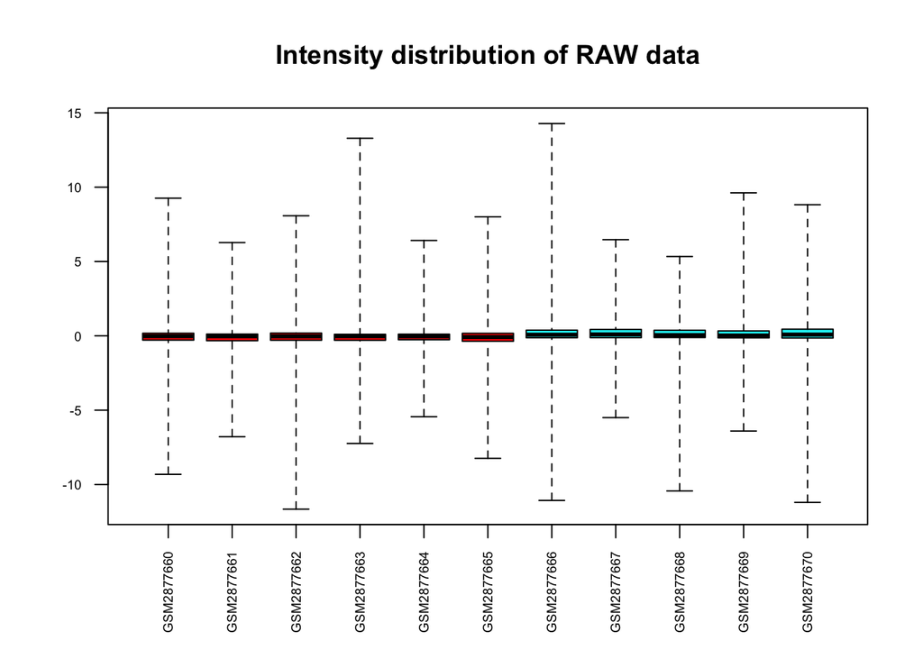

```r
#BOXPLOT
boxplot(rawData, which="all",las=2, main="Intensity distribution of RAW data",
        cex.axis=0.6, col=sampleColor, names=sampleNames)
```

We do a hierarquical clustering:

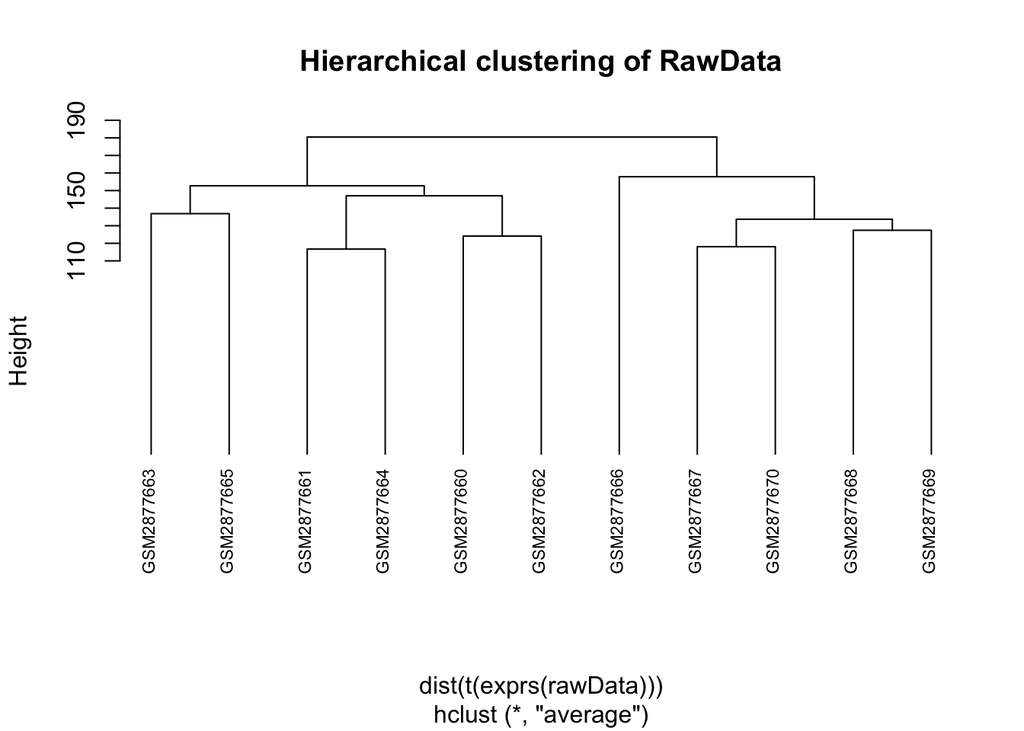

```r
#HIERARQUICAL CLUSTERING
clust.euclid.average <- hclust(dist(t(exprs(rawData))),method="average")
plot(clust.euclid.average, labels=sampleNames, main="Hierarchical clustering of RawData",
     cex=0.7,  hang=-1)
```

And a principal component analysis:

[figure not shown]

```r
#PRINCIPAL COMPONENT ANALYSIS
plotPCA <- function ( X, labels=NULL, colors=NULL, dataDesc="", scale=FALSE, formapunts=NULL, myCex=0.8,...)
{
  pcX<-prcomp(t(X), scale=scale) # o prcomp(t(X))
  loads<- round(pcX$sdev^2/sum(pcX$sdev^2)*100,1)
  xlab<-c(paste("PC1",loads[1],"%"))
  ylab<-c(paste("PC2",loads[2],"%"))
  if (is.null(colors)) colors=1
  plot(pcX$x[,1:2],xlab=xlab,ylab=ylab, col=colors, pch=formapunts,
       xlim=c(min(pcX$x[,1])-100000, max(pcX$x[,1])+100000),ylim=c(min(pcX$x[,2])-100000, max(pcX$x[,2])+100000))
  text(pcX$x[,1],pcX$x[,2], labels, pos=3, cex=myCex)
  title(paste("Plot of first 2 PCs for expressions in", dataDesc, sep=" "), cex=0.8)
}

plotPCA(exprs(rawData), labels=targets$sampleNames, dataDesc="raw data", colors=sampleColor,
        formapunts=c(rep(16,4),rep(17,4)), myCex=0.6)
```

### Normalization of the raw data

We need to normalize the data. To do so we could use the rma function.

```r
# eset_rma <- rma(rawData)
```

But in my case it didn’t work, but I found another function in order to do so:

```r
BiocManager::install("affydata")
eset <- normalize(rawData)
```

### Quality assessment of the normalized data

Now we check the quality of the normalized data, firstly by doing a boxplot:

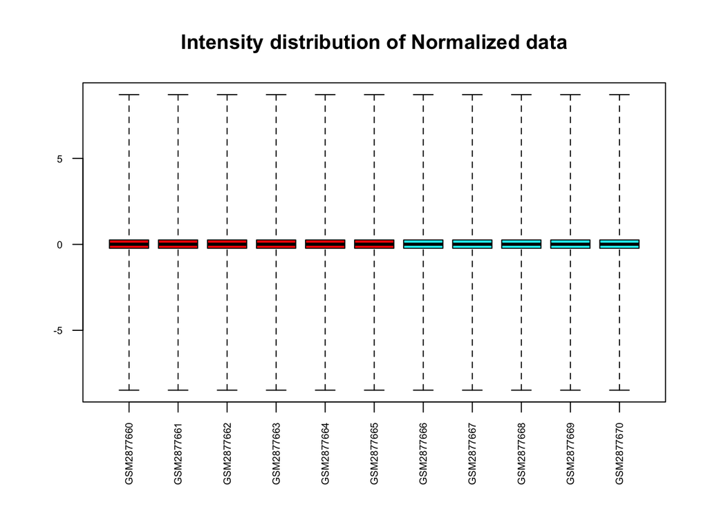

```r
#BOXPLOT
boxplot(eset, las=2, main="Intensity distribution of Normalized data", cex.axis=0.6,
        col=sampleColor, names=sampleNames)
```

We can also do a hierarquical clustering of the normalized data:

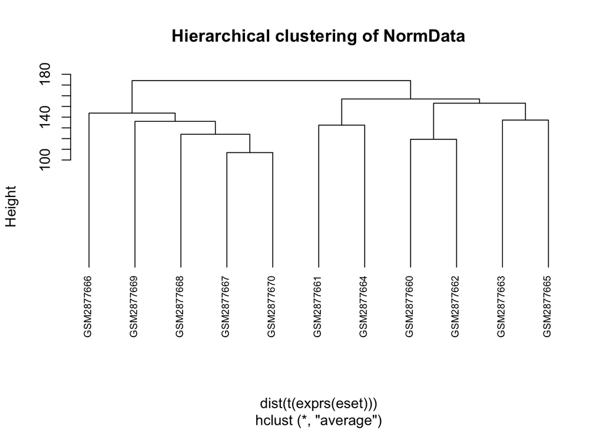

```r
#HIERARQUICAL CLUSTERING

clust.euclid.average <- hclust(dist(t(exprs(eset))),method="average")
plot(clust.euclid.average, labels=sampleNames, main="Hierarchical clustering of NormData",
     cex=0.7,  hang=-1)
```

And as we did for the raw data, we can also do a principal component analysis:

```r
#PRINCIPAL COMPONENT ANALYSIS

plotPCA <- function ( X, labels=NULL, colors=NULL, dataDesc="", scale=FALSE, formapunts=NULL, myCex=0.8,...)
{
  pcX<-prcomp(t(X), scale=scale) # o prcomp(t(X))
  loads<- round(pcX$sdev^2/sum(pcX$sdev^2)*100,1)
  xlab<-c(paste("PC1",loads[1],"%"))
  ylab<-c(paste("PC2",loads[2],"%"))
  if (is.null(colors)) colors=1
  plot(pcX$x[,1:2],xlab=xlab,ylab=ylab, col=colors, pch=formapunts,
       xlim=c(min(pcX$x[,1])-10, max(pcX$x[,1])+10),ylim=c(min(pcX$x[,2])-10, max(pcX$x[,2])+10))
  text(pcX$x[,1],pcX$x[,2], labels, pos=3, cex=myCex)
  title(paste("Plot of first 2 PCs for expressions in", dataDesc, sep=" "), cex=0.8)
}
```

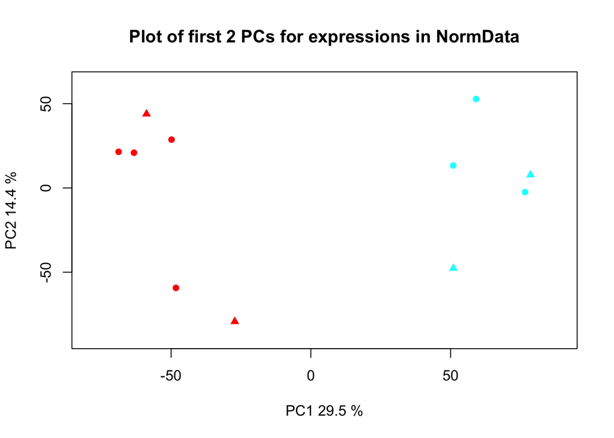

```r
plotPCA(exprs(eset), labels= targets$sampleNames, dataDesc="NormData", colors=sampleColor,
        formapunts=c(rep(16,4),rep(17,4)), myCex=0.6)
```

### Identification of differentially expressed genes

In order to identify the genes that are differentialy expressed, the lima package is required.

```r
require (limma)
```

#### Linear models and comparisons

We’ll need to create a contast matrix with the linear model of the data. We’ll also need a comparison matrix, which will contain the comparisons between the differnet groups data, so in this case there will only be one comparison as we only have two types of samples. And we’ll also fit the model

```r
#CONTRAST MATRIX.lINEAR MODEL
treat <- targets$Type
lev <- factor(treat, levels = unique(treat))
design <-model.matrix(~0+lev)
colnames(design)<-c("Fertile", "Subfertile")
rownames(design) <- targets$SampleName
print(design)
```

```
##            Fertile Subfertile
## GSM2877660       1          0
## GSM2877661       1          0
## GSM2877662       1          0
## GSM2877663       1          0
## GSM2877664       1          0
## GSM2877665       1          0
## GSM2877666       0          1
## GSM2877667       0          1
## GSM2877668       0          1
## GSM2877669       0          1
## GSM2877670       0          1
## attr(,"assign")
## [1] 1 1
## attr(,"contrasts")
## attr(,"contrasts")$lev
## [1] "contr.treatment"
```

```r
#COMPARISON
cont.matrix1 <- makeContrasts (
  Fertile.vs.Subfertile = Fertile-Subfertile,
  levels=design)
comparison1 <- "Effect of Induction"
```

The matrices could also be generated this way:

```
##### Design matrix

design<-matrix(
  c(1,1,1,1,1,1,0,0,0,0,0,
    0,0,0,0,0,0,1,1,1,1,1),
  nrow=11,byrow=F)
design2 <-model.matrix(~ 0+targets$Type) #We put a 0 as there isn't an intercept
colnames(design)<- colnames(design2)<-c("Fer", "Subfer")
rownames(design) <- rownames(design2)<- targets$SampleName
print(design); print(design2)


##### Contrast matrix

cont.matrix <- makeContrasts (
  FerSub = Fer-Subfer,
  levels=design)
```

```r
#MODEL FIT
fit1 <- lmFit(eset, design)
fit.main1 <- contrasts.fit(fit1, cont.matrix1)
fit.main1 <- eBayes(fit.main1)
```

#### Toptables

```r
#FILTER BY FALSE DISCOVERY RATE AND FOLD CHANGE
topTab <-  topTable (fit.main1, number=nrow(fit.main1), coef="Fertile.vs.Subfertile", adjust="fdr",lfc=abs(3))
```

#### Volcano plots

In order to visualize those genes that might be differentially expressed, we can do it through volcano plots.

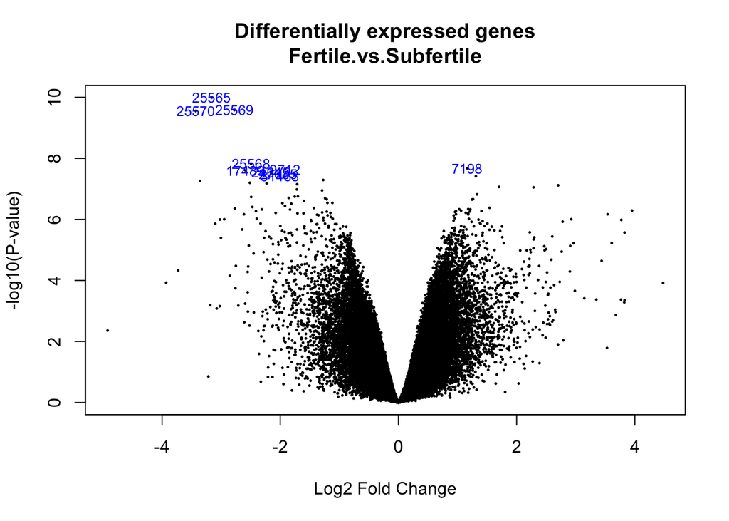

```r
volcanoplot(fit.main1, highlight=10, names=fit.main1$ID,
            main = paste("Differentially expressed genes", colnames(cont.matrix1), sep="\n"))
```

### Data annotation

To annotate the data, we use BiocManager to install the necessary package.

In my case I tried installing different packages but in all the cases they didn’t work properly. I installed different versions of the complete genome for Bos taurus. The packages were:

- MeSH.Bta.eg.d
- TxDb.Btaurus.UCSC.bosTau8.refGene

We would have to continue with something like this:

```
BiocManager::install("MeSH.Bta.eg.db")
require(MeSH.Bta.eg.db)

ls("package:MeSH.Bta.eg.db")

all_anota<-data.frame(exprs(eset))
contents(MeSH.Bta.eg.db)
Annot <- data.frame(SYMBOL=sapply(contents(MeSH.Bta.egSYMBOL), paste, collapse=", "),
                    DESC=sapply(contents(MeSH.Bta.egGENENAME), paste, collapse=", "),
                    UNIPROT=sapply(contents(MeSH.Bta.egUNIPROT), paste, collapse=", "))
Annot<-Annot[!Annot$SYMBOL=="NA",]
Annot<-Annot[!Annot$DESC=="NA",]
head(Annot)

anotaGenes <- merge(Annot,all_anota, by.x=0,by.y=0)
head(anotaGenes)
write.table(anotaGenes, file ="data.ann.txt",sep="\t")

rownames(anotaGenes) <- anotaGenes[,1]
anotaGenes <- anotaGenes[,-1]
anotaGenes.end <- merge(anotaGenes, topTab, by.x=0,by.y=0)
#reordenamos las columnas
topTab.end <- anotaGenes.end[,c(1:3,12:17,4:11)]
topTab.end <- topTab.end[order(-topTab.end$B),]

rownames(topTab.end) <- topTab.end[,1]
topTab.end <- topTab.end[, -1]
write.csv(topTab.end, file = file.path(resultsDir,"TopTable.end.csv"))




probesAvsB <- rownames(topTab_AvsB)[1:10]
anotAvsB <- select(hgu133a.db, probesAvsB, columns = c("ENTREZID", "SYMBOL", "GENENAME"))
```

# Results

Here we can see the differences from the boxplots of the raw data and the normalized data:

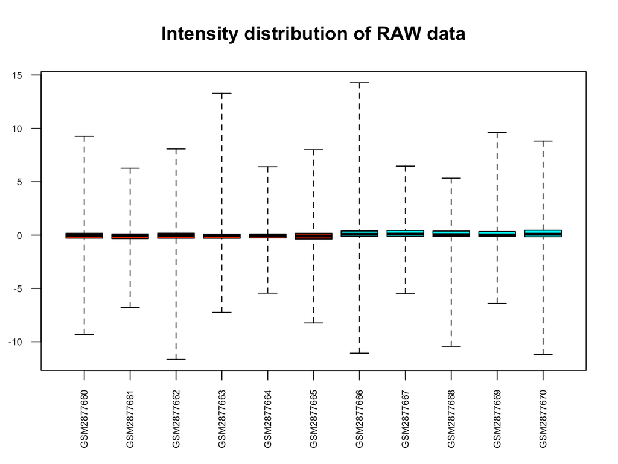

/Users/juditcampsbruch/Documents/BDBI/2n/3r_trim/Omics_Techniques/Camps_Judit-OmicsTechniques/Exercise_3/GSE107741/results

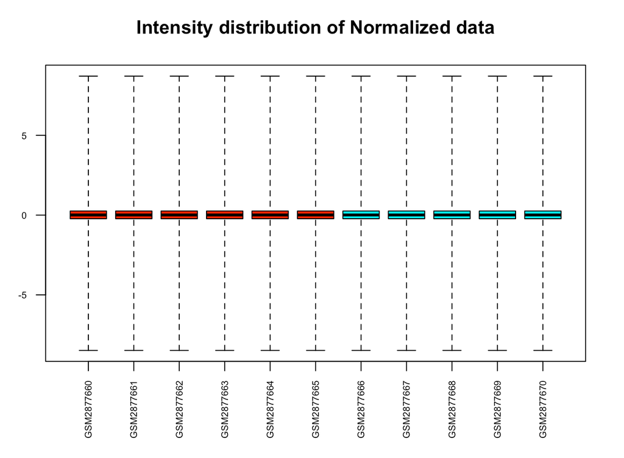

/Users/juditcampsbruch/Documents/BDBI/2n/3r_trim/Omics_Techniques/Camps_Judit-OmicsTechniques/Exercise_3/GSE107741/results

If we also compare the clusterings of the raw data and the normalized data, we can see some differences in the clusters:

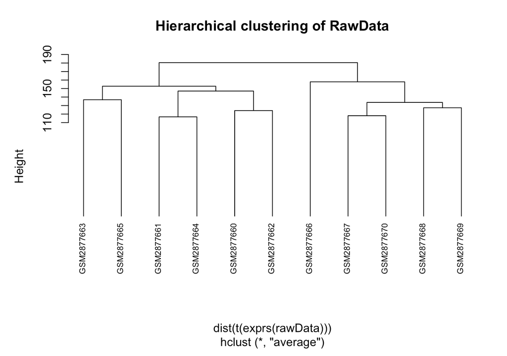

/Users/juditcampsbruch/Documents/BDBI/2n/3r_trim/Omics_Techniques/Camps_Judit-OmicsTechniques/Exercise_3/GSE107741/results

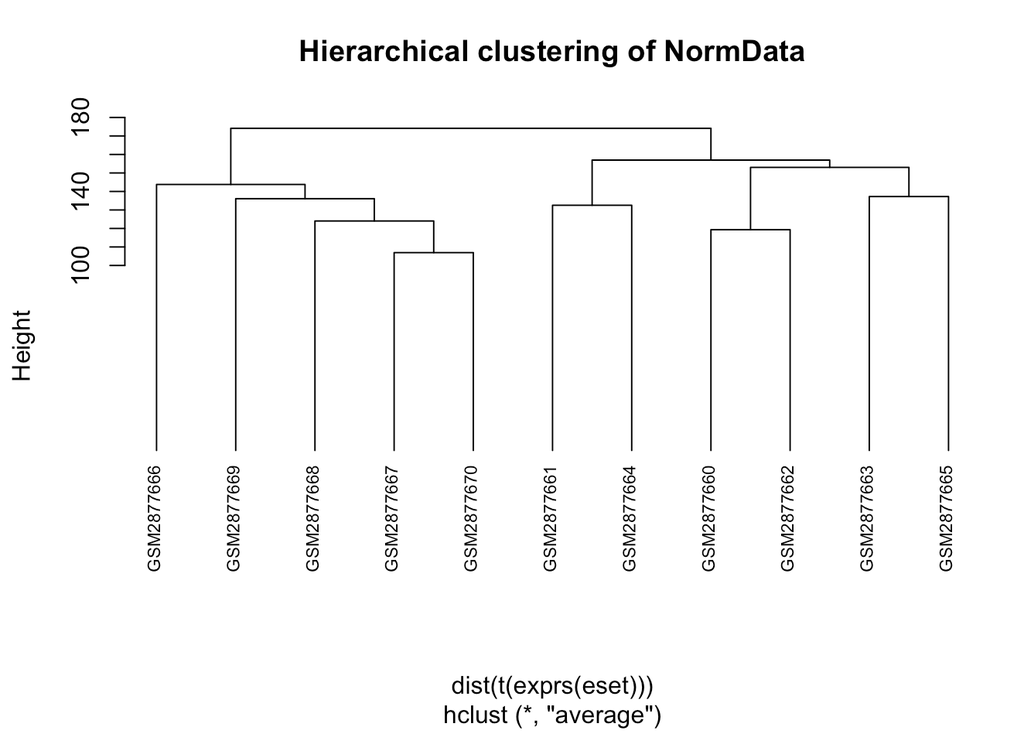

/Users/juditcampsbruch/Documents/BDBI/2n/3r_trim/Omics_Techniques/Camps_Judit-OmicsTechniques/Exercise_3/GSE107741/results

With the PCA plot of the normalized data we can see that there is a separation between both groups (fertile and subfertile):

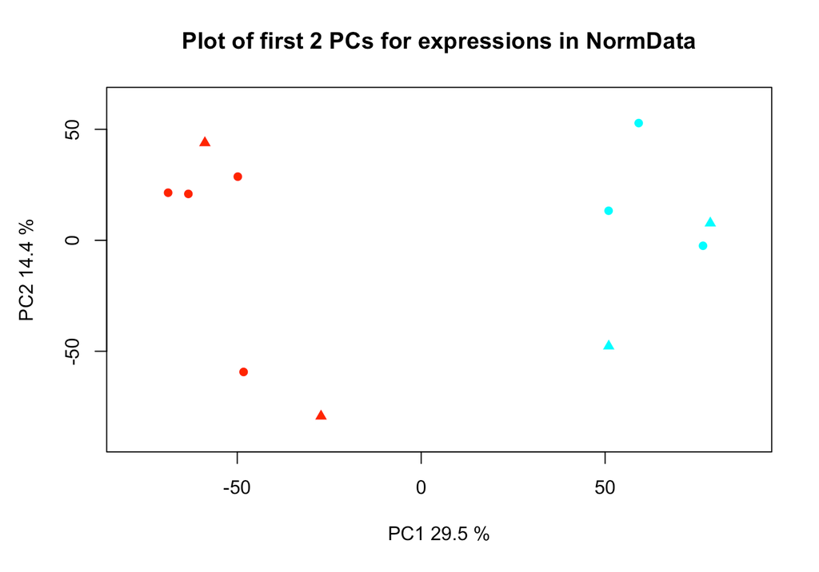

/Users/juditcampsbruch/Documents/BDBI/2n/3r_trim/Omics_Techniques/Camps_Judit-OmicsTechniques/Exercise_3/GSE107741/results

With the volcano plots we are plotting the significance versus the fold-change of the data replicates. Those data points that have a low p-value, and so are significant, will appear on the top of the plot. In this case we can see that we obtain some significant genes.

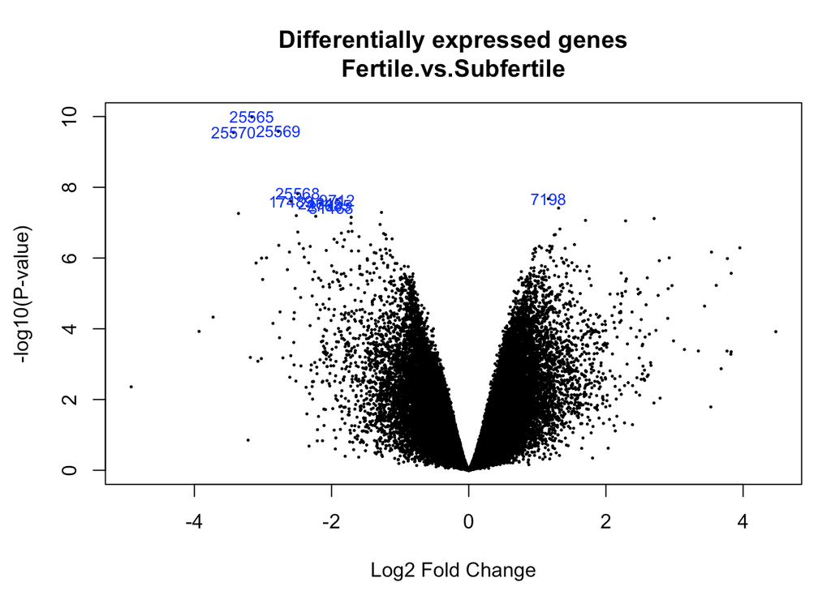

/Users/juditcampsbruch/Documents/BDBI/2n/3r_trim/Omics_Techniques/Camps_Judit-OmicsTechniques/Exercise_3/GSE107741/results

# Conclusions

We can say that, as shown in the previous plots, there is the existance of some genes that may lead to having different types of cows that might be fertile or subfertile. These genes are those shown in the volcano plot as significant.